# Simulación de variables Aleatorias. Metódo de inversión y aceptación-rechazo.

Beltran Henry, Burbano Joel, Guaman Ronny

24/6/2021

### Ejercicios de fin de práctica

**4. Escribir el codigo necesario para generar, por el método de inversión, una muestra de $n$ observaciones de una distribución Cauchy.**

a.Generar una muestra de $10^4$ observaciones y obtener el tiempo de CPU.

Consideramos primero el siguiente código:

```r
ddcauchy <- function(x){ #Función densidad f
  1/(pi*(1+x^2))
}

rdcauchy <- function(){
  # Simulación por inversión
  U <- runif(1)
  return(tan(pi*(U-0.5)))#Inversa
}

rdcauchyn <- function(n = 10000){
  # Simulación n valores de la distribución de Cauchy
  x <- numeric(n) #vector del números con n elementos
  for(i in 1:n) x[i]<-rdcauchy()
  return(x)
}

set.seed(1)
system.time(x <- rdcauchyn(10000))
```

```
##    user  system elapsed
##    0.06    0.00    0.06
```

2. Representar el histograma (limitar el rango, e.g. $xlim = c(-10, 10)$) y compararlo con la densidad teórica $(dcauchy)$.

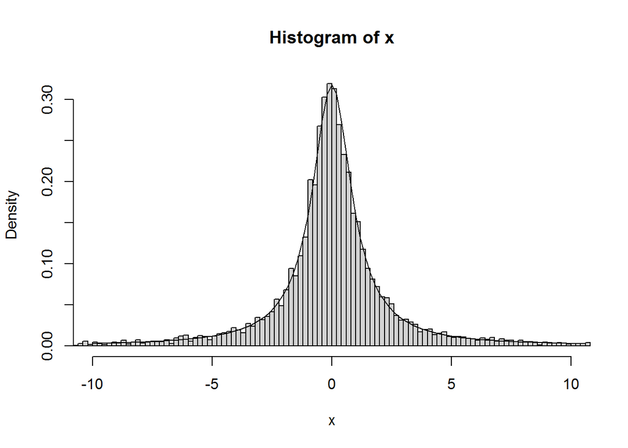

```r
hist(x,breaks = "FD", freq = FALSE,xlim = c(-10, 10))
curve(ddcauchy(x), add = TRUE)
```

3. Obtener conclusiones sobre la existencia de una media teórica a partir de la media muestral aproximada por simulación (estudiar la convergencia de la media muestral ). Suponiendo que el vector x contiene las simulaciones, estudiar la convergencia de la media muestralmediante el gráfico: $plot(1:nsim,cumsum(x)/(1:nsim), type="1", ylab="Media muestral",xlab="N° de simulaciones")$

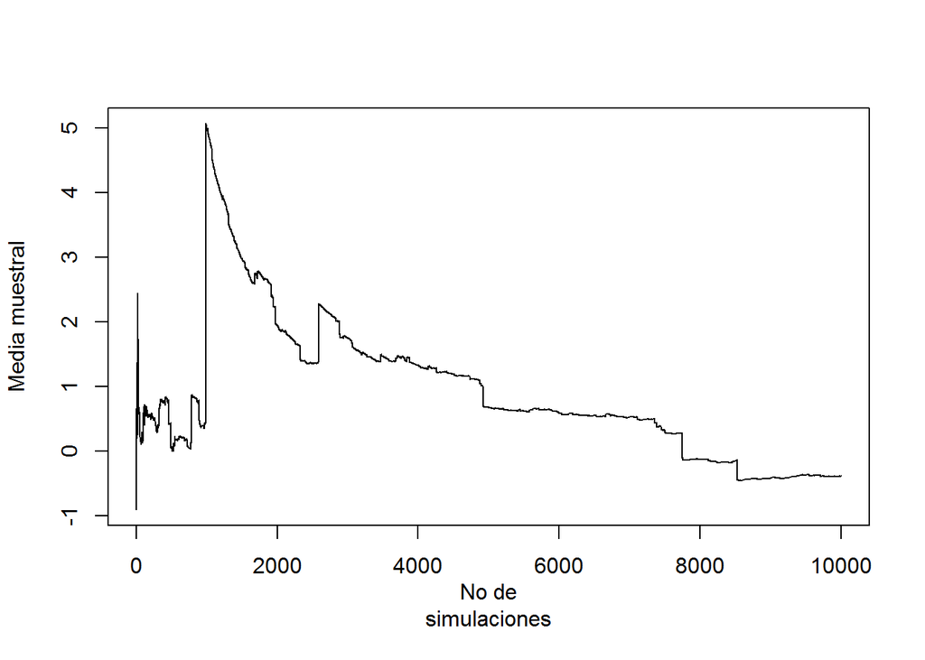

```r
nsim=10000
plot(1:nsim, cumsum(x)/(1:nsim), type="l", ylab="Media muestral", xlab="No de
simulaciones")
```

Con esto podemos ver la distribucion de cauchy no tiene una media muestral a la que converge

**5. El tiempo de respuesta (en centésimas de segundo) de un servidor de bases de datos es una variable con función de densidad:**
$$\begin{aligned}
f(x)= xe^{-x} \quad si \quad x\geq0
\end{aligned}$$
**Escribir el código necesario para generar, por el método de aceptación-rechazo, una muestra de n observaciones de esta distribución empleando como densidad auxiliar una exponencial:**
$$\begin{aligned}
g(x)= \lambda e^{-\lambda x} \quad si \quad x\geq0
\end{aligned}$$

1. Aproximar numéricamente el parámetro óptimo $(\lambda_{opt} < 1)$ y la cota óptima $(c_{opt})$ de la densidad auxiliar y compararlos con los valores teóricos: $\lambda_{opt} = \frac{1}{2}$ y $c_{opt} = \frac{4}{e}$.

Obtengamos $c$ óptimo y $\lambda$ óptimo

```r
f1 <- function(x=1){
  y <- numeric(1)
   if(x>=0){
    y <- x*exp(-x)
  }
  return(y)
}
g <- function(x=1, lambda=1){
  if(x>=0){
    y <- lambda* exp(-lambda*x)
  }
  return(y)
}

fopt <- function(lambda) {
  # Obtiene c fijado lambda
  optimize(f = function(x){f1(x)/g(x,lambda)},
           maximum=TRUE, interval=c(0,2))$objective
}

# Encontar lambda que minimiza
res <- optimize(f=function(x){fopt(x)}, interval=c(0,2))
lambda.opt <- res$minimum
c.opt <- res$objective
```

Ahora los comparamos con los valores teóricos

```r
#Para c óptimo
abs(c.opt-(4/exp(1)))
```

```
## [1] 8.862386e-10
```

```r
#Para lambda óptimo
abs(lambda.opt-0.5)
```

```
## [1] 8.704559e-06
```

Vemos que en ambos casos obtenemos una aproximación bastante buena.

2. Generar una muestra de $1000$ observaciones de la distribución de interés tomando como semilla inicial los cuatro primeros dígitos del DNI. Obtener el tiempo de CPU que tarda en generar la secuencia y calcular el número medio de generaciones de la distribución auxiliar.

Para ello generemos el método de aceptación y rechazo

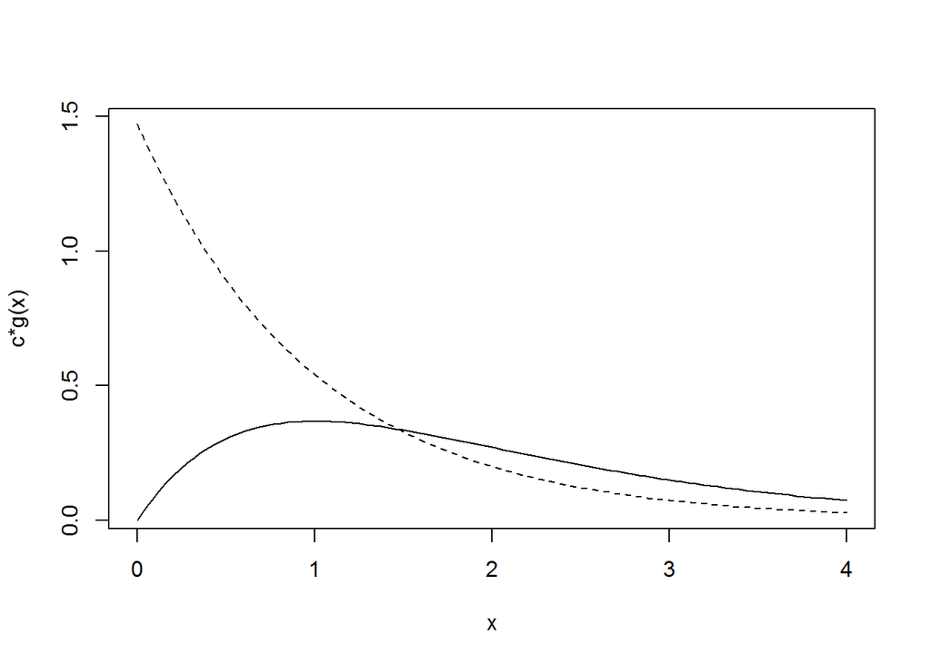

```r
#Simulación por inversión
#Exponencial
rdexp <- function(lambda=1){
  U <- runif(1)
  return(-log(1-U)/lambda)
}

rf1Distr <- function() {
# Simulación por aceptación-rechazo
# Funcion de distribución del ejercicio a partir de exponencial
  while (TRUE) {
    U <- runif(1)
    X <- rdexp(lambda.opt)
    ngen <<- ngen + 1
    if (c.opt*U*g(X)/f1(X) <= 1) return(X)
  }
}

rf1 <- function(n=1000) {
# Simulación n valores
    x <- numeric(n)
    ngen <<- 0
    for(i in 1:n) x[i]<-rf1Distr()
    return(x)
}
curve((4/exp(1))*dexp(x), ylab = "c*g(x)", xlim=c(0,4), lty = 2)
curve(expr = f1,from = 0, to = 4,n = 100, add = TRUE)
```

Por tanto generemos una muestra de $1000$ observaciones

```r
set.seed(1722)
nsim <- 1000


system.time(x <- rf1(nsim))
```

```
##    user  system elapsed
##    0.05    0.00    0.06
```

```r
# Nº generaciones
{
cat("\nNº de generaciones = ", ngen)
cat("\nNº medio de generaciones = ", ngen/nsim)
cat("\nProporción de rechazos = ", 1-nsim/ngen, "\n")
}
```

```
##
## Nº de generaciones =  1412
## Nº medio de generaciones =  1.412
## Proporción de rechazos =  0.2917847
```

3. Representar el histograma y compararlo con la densidad teórica.

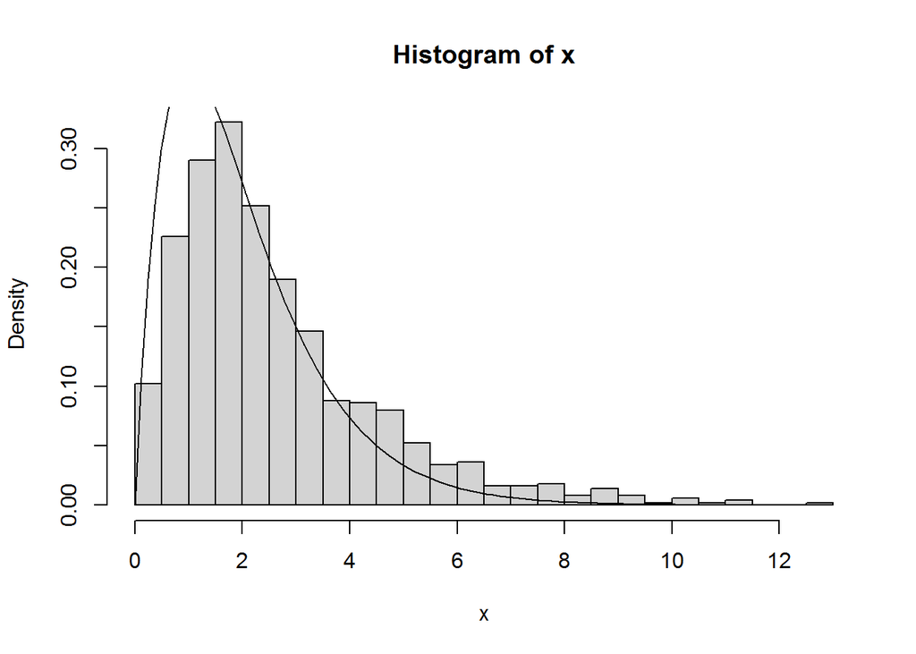

```r
hist(x, breaks="FD", freq=FALSE)
curve(expr = f1,from = 0, to = 12,n = 100, add = TRUE)
```